# Treatment Effect Estimators as Weighted Outcomes

Application 401(k) - average effects

Michael C. Knaus

11/24

*Replication comments:*

- *The many required NxN smoother matrices make this notebook relatively memory intensive (32GB RAM should suffice).*
- *Running the notebook within the replication docker ensures that results perfectly replicate. Otherwise, results might differ depending on which package versions you use.*

This notebook runs the application described in Section 5.1 of [Knaus (2024)](https://arxiv.org/abs/2411.11559). The first part replicates the results presented in the paper, the second part provides supplementary information

# 1. Replication of paper results

## Getting started

First, load packages and set the seed:

```r
if (!require("OutcomeWeights")) install.packages("OutcomeWeights", dependencies = TRUE); library(OutcomeWeights)
if (!require("hdm")) install.packages("hdm", dependencies = TRUE); library(hdm)
if (!require("grf")) install.packages("grf", dependencies = TRUE); library(grf)
if (!require("cobalt")) install.packages("cobalt", dependencies = TRUE); library(cobalt)
if (!require("tidyverse")) install.packages("tidyverse", dependencies = TRUE); library(tidyverse)
if (!require("viridis")) install.packages("viridis", dependencies = TRUE); library(viridis)
if (!require("gridExtra")) install.packages("gridExtra", dependencies = TRUE); library(gridExtra)
library(torch)
library(nnet)
library(AER)
library(rBayesianOptimization)
library(data.table)
source("E:/Mater Thesis/nn_functions.R")
source("E:/Mater Thesis/NuPa_neural_net.R")
source("E:/Mater Thesis/dml_with_smoother_neural_net.R")

set.seed(1234)
```

Next, load the data. Here we use the 401(k) data of the `hdm` package. However, you can adapt the following code chunk to load any suitable data of your choice. Just make sure to call the treatment `D`, covariates `X`, and instrument `Z`. The rest of the notebook should run without further modifications.

```r
data(pension) # Find variable description if you type ?pension in console

# Treatment
D = pension$p401
# Instrument
Z = pension$e401
# Outcome
Y = pension$net_tfa
# Controls
X = model.matrix(~ 0 + age + db + educ + fsize + hown + inc + male + marr + pira + twoearn, data = pension)
var_nm = c("Age","Benefit pension","Education","Family size","Home owner","Income","Male","Married","IRA","Two earners")
colnames(X) = var_nm
```

## Run Double ML

### 2-folds

First, we run all estimators with 2-fold cross-fitting:

```r
# 2 folds
dml_2f = dml_with_smoother_neural_net(Y,D,X,Z,
                           n_cf_folds = 2)
```

```
## sigma_y is NA or 0 and scale_loss is TRUE. Disabling loss scaling
## sigma_y is NA or 0 and scale_loss is TRUE. Disabling loss scaling
```

```r
results_dml_2f = summary(dml_2f)
```

```
##           Estimate      SE       t         p
## PLR        14738.8  1449.3 10.1697 < 2.2e-16 ***
## PLR-IV     14935.2  1879.4  7.9469 2.121e-15 ***
## AIPW-ATE   11420.7  1421.7  8.0331 1.058e-15 ***
## Wald-AIPW  11816.8  2388.7  4.9470 7.660e-07 ***
## AIPW-ATT   17243.9  1682.1 10.2513 < 2.2e-16 ***
## AIPW-ATU    9357.4  1519.9  6.1565 7.727e-10 ***
## ---
## Signif. codes:  0 '***' 0.001 '**' 0.01 '*' 0.05 '.' 0.1 ' ' 1
```

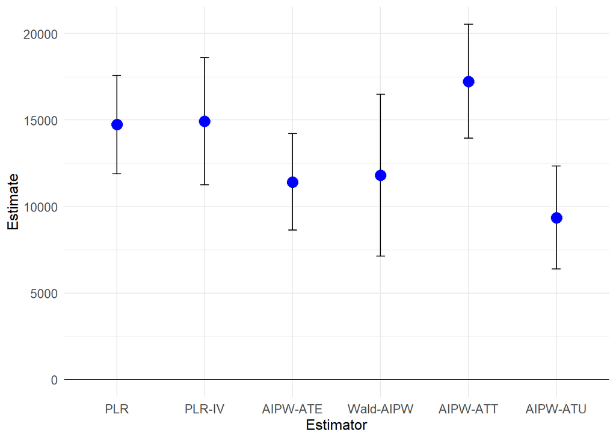

```r
plot(dml_2f)
```

```r
omega_dml_2f = get_outcome_weights(dml_2f)
cat("ω'Y replicates point etimates?",
    all.equal(as.numeric(omega_dml_2f$omega %*% Y),
      as.numeric(results_dml_2f[,1])
    ))
```

```
## ω'Y replicates point etimates? Mean relative difference: 0.01661631
```

### 5-fold

Run double ML also with 5-fold cross-fitting:

```r
# 5 folds
dml_5f = dml_with_smoother_neural_net(Y,D,X,Z,
                           n_cf_folds = 5)
```

```
## sigma_y is NA or 0 and scale_loss is TRUE. Disabling loss scaling
## sigma_y is NA or 0 and scale_loss is TRUE. Disabling loss scaling
## sigma_y is NA or 0 and scale_loss is TRUE. Disabling loss scaling
## sigma_y is NA or 0 and scale_loss is TRUE. Disabling loss scaling
## sigma_y is NA or 0 and scale_loss is TRUE. Disabling loss scaling
```

```r
results_dml_5f = summary(dml_5f)
```

```
##           Estimate      SE      t         p
## PLR        13737.9  1492.0 9.2076 < 2.2e-16 ***
## PLR-IV     13168.2  1944.1 6.7734 1.329e-11 ***
## AIPW-ATE   12569.3  1325.6 9.4816 < 2.2e-16 ***
## Wald-AIPW  12318.9  1909.1 6.4527 1.150e-10 ***
## AIPW-ATT   17047.3  2200.0 7.7489 1.018e-14 ***
## AIPW-ATU   10982.6  1191.5 9.2178 < 2.2e-16 ***
## ---
## Signif. codes:  0 '***' 0.001 '**' 0.01 '*' 0.05 '.' 0.1 ' ' 1
```

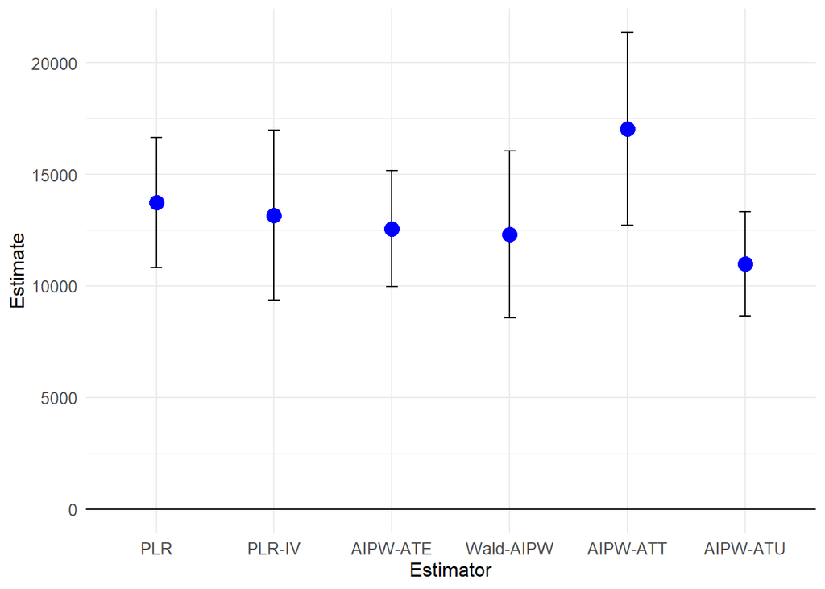

```r
plot(dml_5f)
```

```r
omega_dml_5f = get_outcome_weights(dml_5f)
cat("ω'Y replicates point etimates?",
    all.equal(as.numeric(omega_dml_5f$omega %*% Y),
      as.numeric(results_dml_5f[,1])
    ))
```

```
## ω'Y replicates point etimates? Mean relative difference: 0.01521231
```

## Check covariate balancing

We use the infrastructure of the `cobalt` package to plot Standardized Mean Differences where we need to flip the sign of the untreated outcome weights to make them compatible with the package framework. This is achieved by multiplying the outcome weights by $2 \times D-1$:

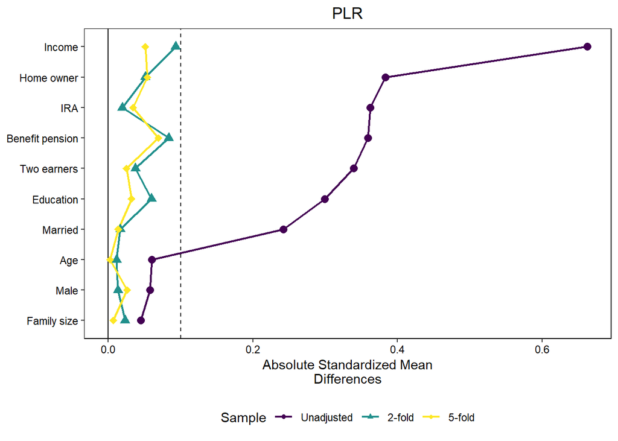

```r
threshold = 0.1

create_love_plot = function(title, index) {
  love.plot(
    D ~ X,
    weights = list(
      "2-fold" = omega_dml_2f$omega[index, ] * (2*D-1),
      "5-fold" = omega_dml_5f$omega[index, ] * (2*D-1)
    ),
    position = "bottom",
    title = title,
    thresholds = c(m = threshold),
    var.order = "unadjusted",
    binary = "std",
    abs = TRUE,
    line = TRUE,
    colors = viridis(3), # color-blind-friendly
    shapes = c("circle", "triangle", "diamond")
  )
}

# Now you can call this function for each plot:
love_plot_plr = create_love_plot("PLR", 1)
love_plot_plriv = create_love_plot("PLR-IV", 2)
love_plot_aipw = create_love_plot("AIPW", 3)
love_plot_waipw = create_love_plot("Wald-AIPW", 4)
love_plot_plr
```

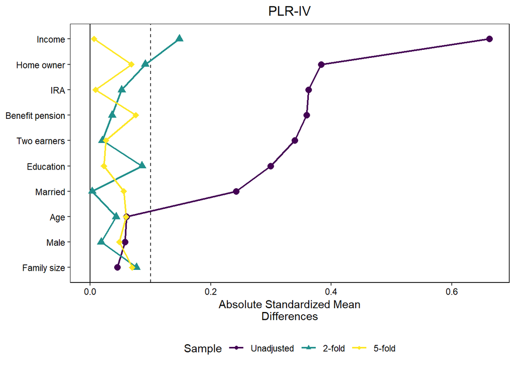

```r
love_plot_plriv
```

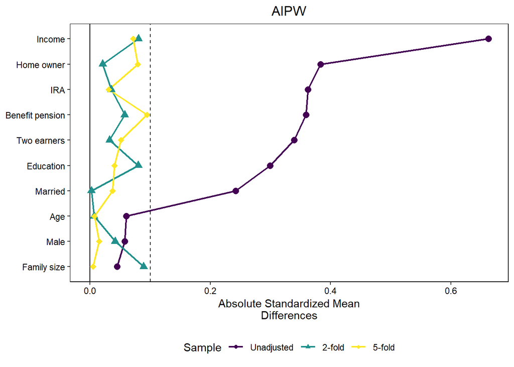

```r
love_plot_aipw
```

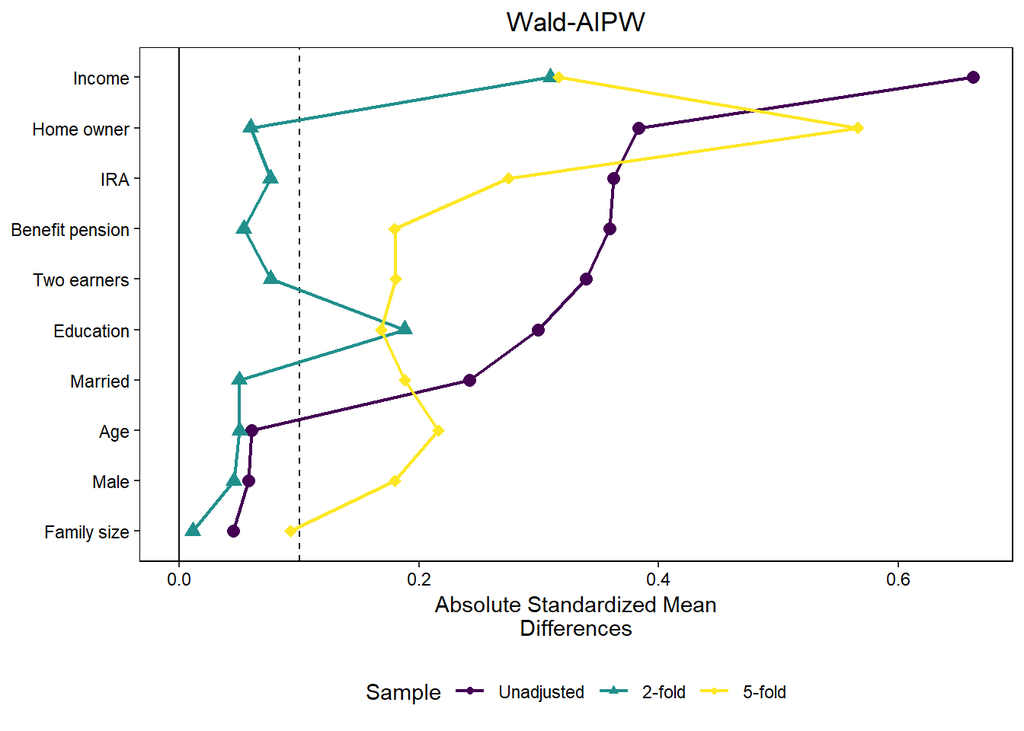

```r
love_plot_waipw
```

Create the combined plot that ends up in the paper as Figure 2:

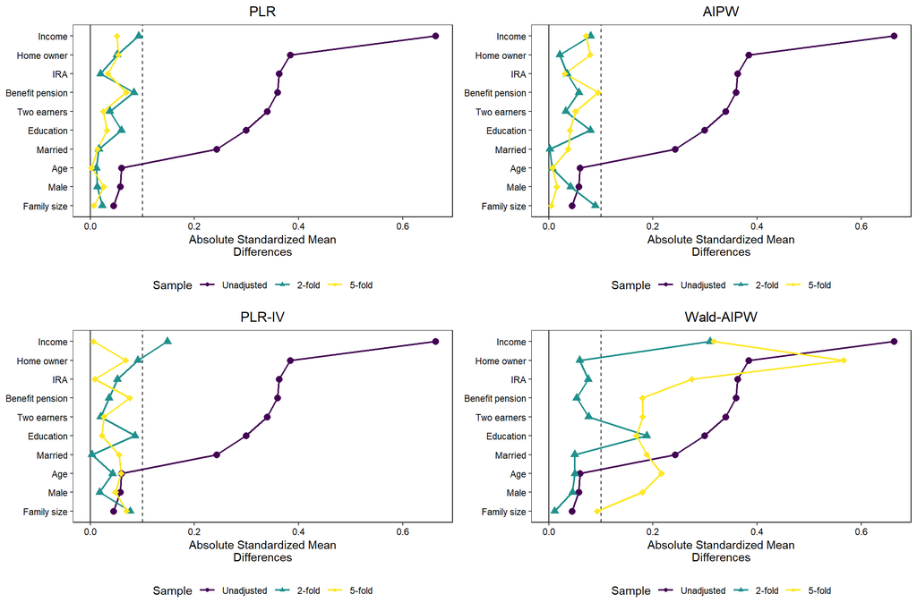

```r
figure2 = grid.arrange(
  love_plot_plr, love_plot_aipw,
  love_plot_plriv,love_plot_waipw,
  nrow = 2
)
```

# 2. Supplementary results

Not done

## Weights descriptives

```r
cat("2-fold: \n")
```

```
## 2-fold:
```

```r
summary(omega_dml_2f)
```

```
##
## Weight summary for estimator PLR
##                           Control    Treated
## Minimum weight            -epsilon*  -epsilon*
## Maximum weight            0.0005     0.0006
## % Negative                0.0172     0.0008
## Sum largest 10%           0.2206     0.1322
## Sum of weights            1.0011     0.9810
## Sum of absolute weights   1.0082     0.9813
## * epsilon <  1e-04
##
## Weight summary for estimator PLR-IV
##                           Control    Treated
## Minimum weight            -0.0008    -0.0003
## Maximum weight            0.0010     0.0008
## % Negative                0.1804     0.0085
## Sum largest 10%           0.3739     0.1583
## Sum of weights            1.1108     0.9696
## Sum of absolute weights   1.9634     0.9729
##
## Weight summary for estimator AIPW-ATE
##                           Control    Treated
## Minimum weight            epsilon*   -0.0037
## Maximum weight            0.0012     0.0250
## % Negative                0.0000     0.0039
## Sum largest 10%           0.1555     0.2875
## Sum of weights            1.0064     0.9780
## Sum of absolute weights   1.0064     1.0184
## * epsilon <  1e-04
##
## Weight summary for estimator Wald-AIPW
##                           Control    Treated
## Minimum weight            -0.0330    -0.1072
## Maximum weight            0.0268     0.0259
## % Negative                0.1569     0.0478
## Sum largest 10%           0.5233     0.3131
## Sum of weights            1.1844     0.8987
## Sum of absolute weights   2.2295     1.2488
##
## Weight summary for estimator AIPW-ATT
##                           Control    Treated
## Minimum weight            -epsilon*  0.0004
## Maximum weight            0.0043     0.0004
## % Negative                0.0264     0.0000
## Sum largest 10%           0.3120     0.1002
## Sum of weights            1.0246     1.0000
## Sum of absolute weights   1.0318     1.0000
## * epsilon <  1e-04
##
## Weight summary for estimator AIPW-ATU
##                           Control    Treated
## Minimum weight            0.0001     -0.0052
## Maximum weight            0.0001     0.0337
## % Negative                0.0000     0.0339
## Sum largest 10%           0.1001     0.3539
## Sum of weights            1.0000     0.9703
## Sum of absolute weights   1.0000     1.0342
```

```r
cat("\n\n5-fold: \n")
```

```
##
##
## 5-fold:
```

```r
summary(omega_dml_5f)
```

```
##
## Weight summary for estimator PLR
##                           Control    Treated
## Minimum weight            -epsilon*  -0.0001
## Maximum weight            0.0006     0.0006
## % Negative                0.0052     0.0019
## Sum largest 10%           0.2332     0.1310
## Sum of weights            0.9987     0.9679
## Sum of absolute weights   1.0007     0.9685
## * epsilon <  1e-04
##
## Weight summary for estimator PLR-IV
##                           Control    Treated
## Minimum weight            -0.0009    -epsilon*
## Maximum weight            0.0008     0.0009
## % Negative                0.1877     0.0035
## Sum largest 10%           0.3455     0.1654
## Sum of weights            0.9769     1.0126
## Sum of absolute weights   1.8944     1.0130
## * epsilon <  1e-04
##
## Weight summary for estimator AIPW-ATE
##                           Control    Treated
## Minimum weight            epsilon*   -0.0011
## Maximum weight            0.0011     0.0068
## % Negative                0.0000     0.0004
## Sum largest 10%           0.1646     0.2264
## Sum of weights            1.0092     0.9888
## Sum of absolute weights   1.0092     0.9909
## * epsilon <  1e-04
##
## Weight summary for estimator Wald-AIPW
##                           Control    Treated
## Minimum weight            -0.0137    -0.1409
## Maximum weight            0.0421     0.0260
## % Negative                0.1475     0.0062
## Sum largest 10%           0.3666     0.3657
## Sum of weights            1.1053     0.8463
## Sum of absolute weights   2.0416     1.3141
##
## Weight summary for estimator AIPW-ATT
##                           Control    Treated
## Minimum weight            -0.0003    0.0004
## Maximum weight            0.0039     0.0004
## % Negative                0.0078     0.0000
## Sum largest 10%           0.3466     0.1002
## Sum of weights            1.0350     1.0000
## Sum of absolute weights   1.0386     1.0000
##
## Weight summary for estimator AIPW-ATU
##                           Control    Treated
## Minimum weight            0.0001     -0.0016
## Maximum weight            0.0001     0.0091
## % Negative                0.0000     0.0239
## Sum largest 10%           0.1001     0.2711
## Sum of weights            1.0000     0.9848
## Sum of absolute weights   1.0000     0.9923
```

```r
# cat("\n\n10-fold: \n")
# summary(omega_dml_10f)
```